title: “Advanced Statistical Modeling & Inference: Lesson Guide” author: “@eisamahyari” date: “2025-03-30” start_date: “2025-March-25” editor_options: chunk_output_type: console output: html_document: toc: true toc_float: true number_sections: true code_folding: hide ioslides_presentation: widescreen: true

## Lesson 1: Introduction to Statistical Modeling and Inference

### Overview

#### Objectives

- Understand the purpose of statistical models.
- Learn basic regression concepts.
- Review the idea and importance of uncertainty in estimates.

#### Topics Covered

- What is a statistical model?
- Key elements: predictors, responses, error terms.
- The importance of uncertainty (confidence intervals, noise).

#### Activities

- Walk through a simple linear regression example.
- Discussion: How does noise affect estimates?

### What is a Statistical Model?

- **Definition:**  
  A statistical model is a simplified representation of the real world that helps us understand relationships between variables.
- **Components:**
  - **Predictors (X):** Variables that we think influence an outcome.
  - **Response (Y):** The outcome we want to predict or explain.
  - **Error term:** Captures the natural randomness or noise in the data.
- **Example:**  
  Predicting a person’s weight (Y) based on their height (X).

### Simple Linear Regression: The Basics

- **Model Form:**
  $$Y = \beta_0 + \beta_1 X + \varepsilon$$
  - $\beta_0$: Intercept (baseline value of $Y$ when $X=0$).
  - $\beta_1$: Slope (change in $Y$ per unit change in $X$).
  - $\varepsilon$: Error term (captures noise).
- **Key Idea:**  
  We try to find the best straight line that fits our data points.

### A Simple Example in R

Below we simulate some data and fit a simple linear regression model.  
Notice how the model estimates the relationship between our predictor and response, while also providing measures of uncertainty.

```r
# Simulate data for 100 individuals
n <- 100
height <- rnorm(n, mean = 170, sd = 10)   # Height in cm
true_intercept <- 50                      # Baseline weight (kg)
true_slope <- 0.5                         # Weight increases 0.5 kg per cm of height
noise <- rnorm(n, mean = 0, sd = 5)         # Measurement error

# Calculate weight
weight <- true_intercept + true_slope * height + noise

# Create a data frame
data <- data.frame(height, weight)
head(data)
```

```
##     height   weight
## 1 164.3952 128.6456
## 2 167.6982 135.1335
## 3 185.5871 141.5601
## 4 170.7051 133.6148
## 5 171.2929 130.8883
## 6 187.1506 143.3502
```

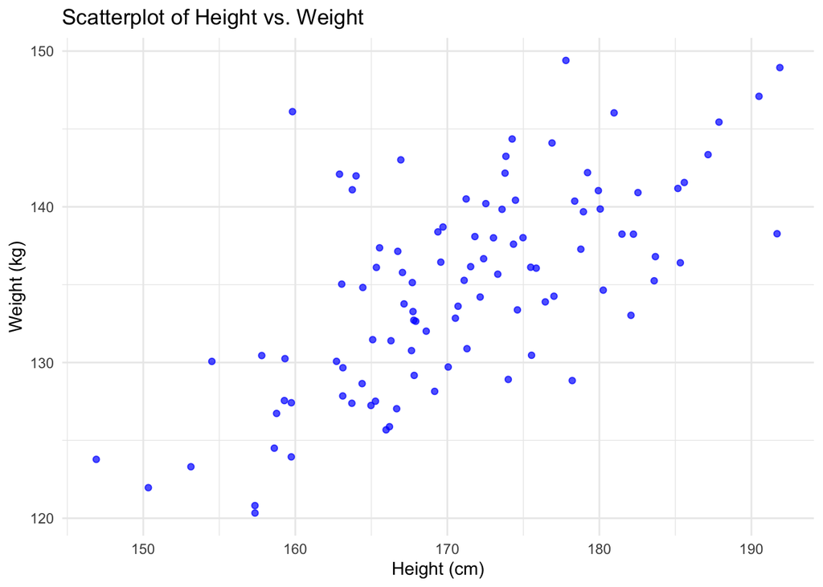

```r
ggplot(data, aes(x = height, y = weight)) +
  geom_point(color = "blue", alpha = 0.7) +
  labs(title = "Scatterplot of Height vs. Weight",
       x = "Height (cm)",
       y = "Weight (kg)") +
  theme_minimal()
```

```r
# Fit the model
model <- lm(weight ~ height, data = data)

# Summarize the model
summary(model)
```

```
##
## Call:
## lm(formula = weight ~ height, data = data)
##
## Residuals:
##     Min      1Q  Median      3Q     Max
## -9.5367 -3.4175 -0.4375  2.9032 16.4520
##
## Coefficients:
##             Estimate Std. Error t value Pr(>|t|)
## (Intercept) 53.94607    9.14588   5.898 5.24e-08 ***
## height       0.47376    0.05344   8.865 3.50e-14 ***
## ---
## Signif. codes:  0 '***' 0.001 '**' 0.01 '*' 0.05 '.' 0.1 ' ' 1
##
## Residual standard error: 4.854 on 98 degrees of freedom
## Multiple R-squared:  0.4451, Adjusted R-squared:  0.4394
## F-statistic:  78.6 on 1 and 98 DF,  p-value: 3.497e-14
```

### Discussion

#### Why is Uncertainty Important?

- Confidence Intervals: They tell us the range within which the true value of our parameters likely lies.
- Decision-Making: A precise estimate (narrow confidence interval) gives us more confidence when making predictions or decisions.
- Real World: Data is messy. Acknowledging uncertainty helps us avoid overconfidence in our conclusions.

#### Key Takeaways

- Statistical Models Simplify Complexity: They help us understand relationships by filtering out some noise, but they can never capture every detail of reality.
- Regression Models Are a Starting Point: They allow us to quantify the relationship between variables.
- Always Consider Uncertainty: Measures like standard errors and confidence intervals are crucial for interpreting the reliability of your estimates.

#### Discussion & Reflection

- Questions to Consider:
- What does the slope tell you about the relationship between height and weight?
- How does the error term impact the model’s predictions?
- Why is it important not to rely solely on the fitted line without considering uncertainty?

## Lesson 2: Fundamentals of Bayesian Inference and Regularization

### Overview

#### Objectives

- Grasp the basics of Bayesian inference.
- Learn priors, likelihoods, and posteriors.
- Understand regularization and shrinkage.

#### Topics Covered

- **Bayesian Inference Basics:**  
  Updating beliefs using prior and data.
- **Regularization & Shrinkage:**  
  Reducing overfitting by “shrinking” estimates.

#### Activities

- Illustrate Bayesian updating with a coin-flip example.
- Visual demonstration of shrinkage effects.

### What is Bayesian Inference?

- **Bayesian Inference:**  
  A method of statistical inference where we update our beliefs (priors) with data (likelihood) to get new beliefs (posteriors).
- **Key Components:**
  - **Prior:** What we believe about a parameter before seeing data.
  - **Likelihood:** How probable the observed data is, given a parameter.
  - **Posterior:** Updated belief about the parameter after considering the data.

### A Simple Coin-Flip Example

Imagine we want to estimate the probability $\theta$ of getting heads when flipping a coin.

- **Prior Belief:**  
  We start with a Beta distribution, $\text{Beta}(\alpha, \beta)$. For example, a uniform prior: $\text{Beta}(1, 1)$.
- **Data (Likelihood):**  
  Suppose we flip the coin 10 times and observe 7 heads.
- **Bayesian Updating:**  
  The posterior is also a Beta distribution: $\text{Beta}(\alpha + \text{heads}, \beta + \text{tails})$.

### Coin-Flip Demo in R

Let’s implement this simple Bayesian update in R.

```r
# Define the prior parameters
alpha_prior <- 1
beta_prior <- 1

# Data: 7 heads out of 10 flips
heads <- 7
flips <- 10
tails <- flips - heads

# Compute posterior parameters
alpha_post <- alpha_prior + heads
beta_post <- beta_prior + tails

# Display the posterior parameters
cat("Posterior: Beta(", alpha_post, ",", beta_post, ")\n")
```

```
## Posterior: Beta( 8 , 4 )
```

#### Visualizing the Prior and Posterior

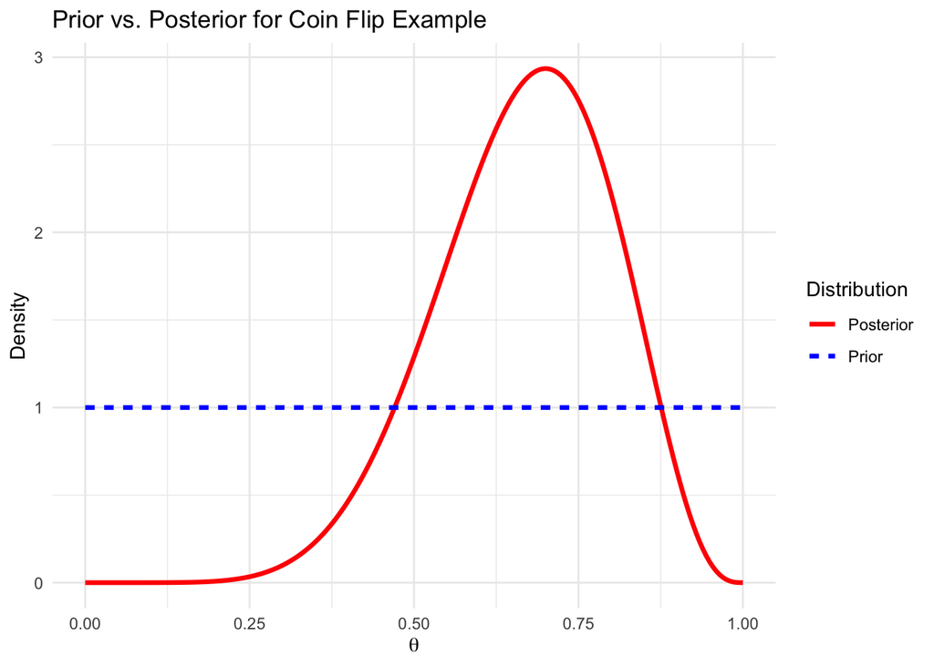

```r
library(ggplot2)
library(scales)

# Create a sequence of theta values
theta <- seq(0, 1, length.out = 200)

# Compute prior and posterior densities
prior_density <- dbeta(theta, alpha_prior, beta_prior)
posterior_density <- dbeta(theta, alpha_post, beta_post)

# Create a data frame for plotting
df <- data.frame(
  theta = rep(theta, 2),
  density = c(prior_density, posterior_density),
  Distribution = factor(rep(c("Prior", "Posterior"), each = length(theta)))
)

ggplot(df, aes(x = theta, y = density, color = Distribution, linetype = Distribution)) +
  geom_line(size = 1.2) +
  scale_color_manual(values = c("Prior" = "blue", "Posterior" = "red")) +
  labs(title = "Prior vs. Posterior for Coin Flip Example",
       x = expression(theta),
       y = "Density") +
  theme_minimal()
```

#### Introduction to Regularization and Shrinkage

- Regularization: A technique used to prevent overfitting by “shrinking” parameter estimates toward zero or another central value.
- Shrinkage: In Bayesian inference, priors can pull estimates towards a central value if the data is weak or noisy.
- Why Regularization Matters:
- Avoid Overfitting: Prevents models from fitting noise in the data.
- Improves Prediction: Yields more robust and generalizable estimates.
- Interpretable Estimates: Especially in high-dimensional settings, shrinkage can help highlight the most important predictors.

#### Demonstrating Shrinkage: A Simple Example

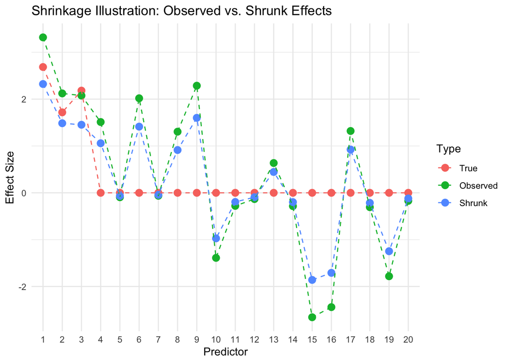

```r
# For demonstration, we simulate "true" coefficients:
set.seed(42)
n_predictors <- 20
# Only 3 predictors have non-zero true effects; the rest are noise.
true_effects <- c(rnorm(3, 2, 0.5), rep(0, n_predictors - 3))
# Simulate noisy estimates for these coefficients
observed_effects <- true_effects + rnorm(n_predictors, 0, 1)

# Visual comparison: observed effects vs. shrinkage (naively shrink towards 0)
# We'll use a simple formula: shrunk_effect = observed_effect * 0.7 (as an illustration)
shrunk_effects <- observed_effects * 0.7

df_effects <- data.frame(
  Predictor = factor(1:n_predictors),
  True = true_effects,
  Observed = observed_effects,
  Shrunk = shrunk_effects
)

library(reshape2)
df_melt <- melt(df_effects, id.vars = "Predictor", variable.name = "Type", value.name = "Effect")

ggplot(df_melt, aes(x = Predictor, y = Effect, color = Type)) +
  geom_point(size = 3) +
  geom_line(aes(group = Type), linetype = "dashed") +
  labs(title = "Shrinkage Illustration: Observed vs. Shrunk Effects",
       x = "Predictor",
       y = "Effect Size") +
  theme_minimal()
```

### Discussion

#### Intuitive Points:

- The observed effects are noisy estimates of the true underlying effects.
- Shrinkage pulls these estimates closer to zero (or another central value), reducing the influence of noise.
- This example is simplistic, but in real applications, Bayesian priors can be tuned to achieve optimal shrinkage.

#### Key Takeaways

- Bayesian Inference: Updates prior beliefs with data to form a posterior distribution.
- Coin-Flip Example: Demonstrates how a Beta prior updates to a Beta posterior with observed data.
- Regularization & Shrinkage: Serve to control overfitting and improve the robustness of model estimates by pulling noisy estimates toward a central value.
- Practical Impact: These concepts form the basis for more advanced modeling techniques that handle complex, high-dimensional data.

#### Discussion & Reflection

- What did the coin-flip example teach you about updating beliefs?
- How does shrinkage help in making our models more reliable?
- Can you think of scenarios where overfitting might lead to misleading conclusions?

## Lesson 3: Introduction to Multilevel (Hierarchical) Models

### Overview

#### Objectives

- Understand multilevel models and their applications.
- Differentiate overall (fixed) vs. group-specific (random) effects.
- Learn the concept of partial pooling and its benefits.

#### Topics Covered

- **Multilevel Data Structures:**  
  Examples: students within schools, repeated measures.
- **Hierarchical Modeling & Partial Pooling:**  
  Sharing information across groups.
- **Benefits & Challenges:**  
  Complexity vs. stability of estimates.

#### Activities

- Explore a multilevel model example (e.g., test scores by school).
- Discussion on pooling information.

### What Are Multilevel Models?

- **Definition:**  
  Multilevel models (also called hierarchical or mixed-effects models) allow us to analyze data that are grouped or clustered.
- **Examples of Grouped Data:**
  - Students within schools.
  - Repeated measures on the same individuals.
  - Patients within hospitals.
- **Why Use Them?**  
  They help us:
  - Capture variability within and between groups.
  - Borrow strength across groups to make more stable estimates (partial pooling).

### Fixed Effects vs. Random Effects

- **Fixed Effects:**
  - Represent overall effects that are constant across all groups.
  - Example: The overall relationship between study time and test scores.
- **Random Effects:**
  - Capture group-specific deviations from the overall effect.
  - Example: Differences in average test scores between schools.
- **Partial Pooling:**
  - Estimates for individual groups are “shrunk” toward the overall mean.
  - Helps avoid overfitting in groups with small sample sizes.

### Simulating Hierarchical Data

Let’s simulate data for students nested within schools. Each school has its own intercept, and student test scores depend on their study hours.

```r
# Load necessary packages
library(ggplot2)
library(lme4)
set.seed(123)

# Simulate data: 10 schools, each with 30 students
n_schools <- 10
students_per_school <- 30

# Overall (fixed) intercept and slope
fixed_intercept <- 50    # Overall average test score when study hours = 0
fixed_slope <- 5         # Increase in test score per study hour

# Random intercept variance (between-school variability)
school_sd <- 10

# Generate school-specific intercepts
school_intercepts <- rnorm(n_schools, mean = 0, sd = school_sd)

# Simulate study hours and test scores
data_list <- lapply(1:n_schools, function(s) {
  study_hours <- rnorm(students_per_school, mean = 5, sd = 2)
  # Test score = overall intercept + school-specific effect + slope * study hours + noise
  test_score <- fixed_intercept + school_intercepts[s] + fixed_slope * study_hours +
    rnorm(students_per_school, mean = 0, sd = 5)
  data.frame(School = factor(s),
             StudyHours = study_hours,
             TestScore = test_score)
})

school_data <- do.call(rbind, data_list)
head(school_data)
```

```
##   School StudyHours TestScore
## 1      1   7.448164  78.16253
## 2      1   5.719628  71.95380
## 3      1   5.801543  67.07598
## 4      1   5.221365  81.34685
## 5      1   3.888318  69.87664
## 6      1   8.573826  81.64883
```

#### Visualize the data

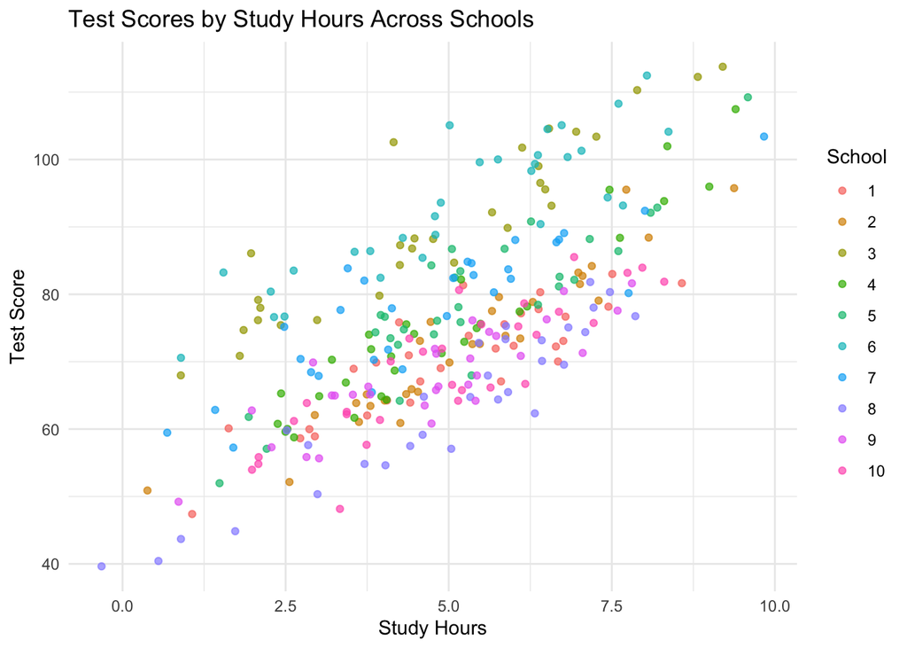

```r
ggplot(school_data, aes(x = StudyHours, y = TestScore, color = School)) +
  geom_point(alpha = 0.7) +
  labs(title = "Test Scores by Study Hours Across Schools",
       x = "Study Hours",
       y = "Test Score") +
  theme_minimal()
```

### Fitting a Multilevel Model

```r
# Fit the linear mixed effects model using lmer
model <- lmer(TestScore ~ StudyHours + (1 | School), data = school_data)
summary(model)
```

```
## Linear mixed model fit by REML ['lmerMod']
## Formula: TestScore ~ StudyHours + (1 | School)
##    Data: school_data
##
## REML criterion at convergence: 1832.3
##
## Scaled residuals:
##     Min      1Q  Median      3Q     Max
## -2.7399 -0.6635 -0.0341  0.5961  3.2985
##
## Random effects:
##  Groups   Name        Variance Std.Dev.
##  School   (Intercept) 88.13    9.387
##  Residual             22.74    4.769
## Number of obs: 300, groups:  School, 10
##
## Fixed effects:
##             Estimate Std. Error t value
## (Intercept)  51.3414     3.0641   16.76
## StudyHours    4.9258     0.1423   34.61
##
## Correlation of Fixed Effects:
##            (Intr)
## StudyHours -0.231
```

### Discussion

#### Intuitive Points:

- The fixed effect for StudyHours represents the average increase in test score per additional study hour.
- The random intercept for School allows each school to have its own baseline score.
- Partial pooling: School intercept estimates are pulled toward the overall average, especially for schools with fewer students.

#### Why Use Multilevel Models?

- Improved Estimation: By borrowing strength across groups, multilevel models provide more stable estimates.
- Addressing Group-Level Variability: They correctly attribute variability to differences within and between groups.
- Flexibility: They can incorporate multiple levels (e.g., students within classes within schools) and additional predictors.

#### Key Takeaways

- Multilevel models are ideal for clustered or grouped data.
- Fixed effects capture overall relationships, while random effects allow for group-specific variation.
- Partial pooling prevents overfitting by shrinking group estimates toward the overall mean.
- The simulation example illustrates how multilevel models handle data with school-level variability.

#### Discussion & Reflection

- How do you think the model would change if we added another predictor (e.g., parental education)?
- Why might it be misleading to ignore the grouping structure in the data?
- Can you think of examples in your field where hierarchical models might be useful?

## Lesson 4: Deep Dive into the R2D2M2 Prior

### Overview

#### Objectives

- Learn how the R2D2M2 prior is constructed.
- Differentiate between global shrinkage (overall regularization) and local shrinkage (individual predictor shrinkage).
- Learn how R² (the proportion of explained variance) is used to set up the prior.
- Appreciate the use of R² for intuitive prior elicitation.

#### Topics Covered

- **R² as a Prior:**  
  Using explained variance to distribute shrinkage.
- **Global vs. Local Shrinkage:**  
  Overall control vs. individual predictor flexibility.
- **Mathematical Overview:**  
  Conceptual explanation of Dirichlet decomposition.

#### Activities

- Diagram of the R2D2M2 framework.
- Discussion: How does joint shrinkage prevent overfitting?

### R² as a Prior

- **R² (Coefficient of Determination):**  
  A measure of how much variance in the outcome is explained by the model.
- **Idea Behind the R2D2M2 Prior:**
  - Specify a prior directly on R².
  - Decompose the total explained variance into contributions from individual predictors.
- **Why R²?**
  - It’s an intuitive measure that researchers already use.
  - Helps in translating domain knowledge into prior settings.

### Global vs. Local Shrinkage

- **Global Shrinkage ($\tau^2$):**  
  Controls the overall level of regularization by shrinking all coefficients collectively.
- **Local Shrinkage ($\phi$ or the Dirichlet components):**  
  Allocates the overall explained variance to individual predictors, allowing some coefficients to “escape” heavy shrinkage if supported by data.
- **Combined Effect:**
  - Ensures noise (small or spurious effects) is pulled toward zero.
  - Retains strong signals by allowing them to have larger individual variance components.

### Conceptual Diagram of the R2D2M2 Prior

- **Step 1:** Assign a prior on R² (e.g., using a Beta distribution).
- **Step 2:** Convert R² to the overall explained variance ($\tau^2$).
- **Step 3:** Decompose $\tau^2$ into parts for each predictor using a Dirichlet distribution.
- **Step 4:** Each predictor’s coefficient gets a variance component that is the product of the global variance and its local allocation.

*Imagine a pie chart where the whole pie is $\tau^2$ (global variance) and each slice (given by a Dirichlet draw) represents the contribution for a predictor.*

### Simulation: Decomposing Variance with Dirichlet

We now simulate the local shrinkage component using a Dirichlet distribution. Suppose we have 5 predictors and a symmetric Dirichlet prior.

```r
# Load required package
if (!require("MCMCpack")) install.packages("MCMCpack", repos='http://cran.us.r-project.org')
library(MCMCpack)

# Number of predictors
n_predictors <- 5

# Set a symmetric Dirichlet hyperparameter (alpha = a_pi)
a_pi <- 1  # Uniform, non-informative

# Draw a single sample from Dirichlet(alpha, alpha, ..., alpha)
dirichlet_sample <- rdirichlet(1, rep(a_pi, n_predictors))
dirichlet_sample
```

```
##            [,1]      [,2]      [,3]       [,4]      [,5]
## [1,] 0.03767916 0.2499058 0.5541456 0.01987357 0.1383959
```

### Visualizing the Dirichlet Allocations

Let’s simulate many draws to see the distribution of these local shrinkage components.

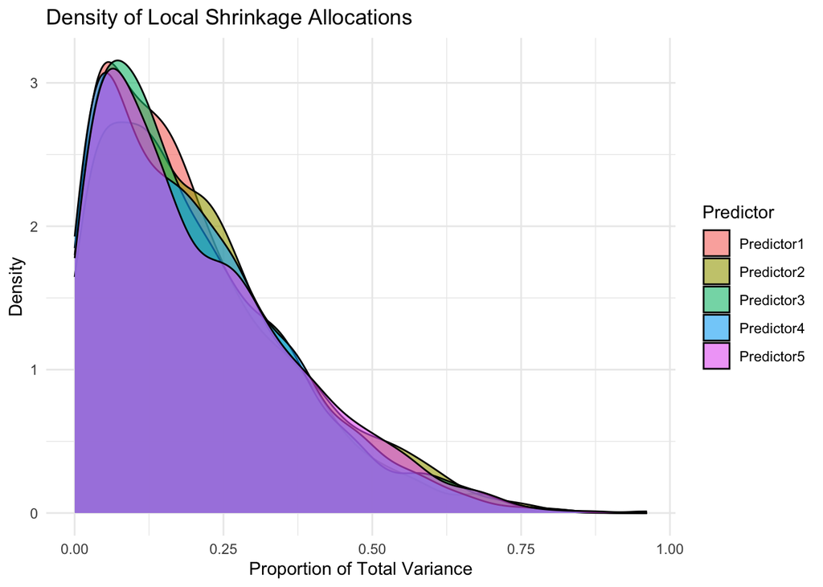

```r
# Simulate 1000 draws
n_draws <- 1000
dirichlet_draws <- rdirichlet(n_draws, rep(a_pi, n_predictors))
dirichlet_df <- data.frame(dirichlet_draws)
names(dirichlet_df) <- paste0("Predictor", 1:n_predictors)

# Reshape data for plotting
library(reshape2)
dirichlet_melt <- melt(dirichlet_df, variable.name = "Predictor", value.name = "Allocation")
# Plot density for each predictor's allocation
ggplot(dirichlet_melt, aes(x = Allocation, fill = Predictor)) +
  geom_density(alpha = 0.6) +
  labs(title = "Density of Local Shrinkage Allocations",
       x = "Proportion of Total Variance",
       y = "Density") +
  theme_minimal()
```

## Lesson 5: Understanding the Kimma Framework for RNA-seq Analysis

### Overview

#### Objectives

- Introduce RNA-seq and the concept of Differential Gene Expression (DEG) analysis.
- Understand the basics of linear mixed effects models in the context of RNA-seq.
- Learn how Kimma incorporates random effects (e.g., donor effects) and covariance structures (e.g., kinship) into the analysis.
- Explore a simulated paired design to appreciate the benefits of adjusting for relatedness.

#### Topics Covered

- **RNA-seq & DEG Analysis:**  
  Basics and importance.
- **Mixed Effects Models in Bioinformatics:**  
  Handling repeated measures, paired designs, covariates.
- **Kinship Covariance:**  
  Adjusting for genetic relatedness.

#### Activities

- Review a case study (e.g., tuberculosis dataset).
- Discuss consequences of ignoring kinship in analysis.

### RNA-seq and DEG Analysis

- **RNA-seq Overview:**
  - RNA-seq measures gene expression levels across the transcriptome.
  - It provides counts or normalized expression values (e.g., log2 CPM) for thousands of genes.
- **Differential Gene Expression (DEG):**
  - DEG analysis aims to identify genes that are expressed differently between conditions (e.g., Treatment vs. Control).
- **Challenges in RNA-seq:**
  - High-dimensionality: thousands of genes but relatively few samples.
  - Complex study designs: paired samples, repeated measures, and the presence of covariates.
  - Genetic relatedness: individuals may be related, introducing correlation (kinship) into the data.

### Linear Mixed Effects Models in RNA-seq

- **Why Mixed Effects?**
  - To account for both fixed effects (e.g., treatment) and random effects (e.g., donor variability).
  - **Example:** In paired designs, the same donor provides samples in different conditions, so donor is modeled as a random effect.
- **Kimma Framework:**
  - Kimma is an R package that implements flexible linear (and mixed effects) models for RNA-seq.
  - It supports:
    - Univariate and multivariate models.
    - Incorporation of covariates and gene-level weights.
    - Random effects, including covariance random effects (e.g., kinship).
    - Model fit metrics such as AIC.

### Simulating a Paired RNA-seq Dataset

We’ll simulate a small dataset to illustrate the basic idea behind mixed effects modeling in RNA-seq analysis.

- **Design:**
  - Two conditions: Control and Treatment.
  - Paired design: Each donor provides a sample in both conditions.
  - One gene (for simplicity) with a treatment effect and a donor-specific random effect.

```r
set.seed(123)

# Parameters
n_donors <- 10   # Number of donors
conditions <- c("Control", "Treatment")
n_samples <- n_donors * length(conditions)

# Create a donor variable (each donor appears twice)
Donor <- rep(1:n_donors, each = length(conditions))

# Create a condition variable (Control and Treatment for each donor)
Condition <- rep(conditions, times = n_donors)

# Fixed effect: true treatment effect (e.g., increase in gene expression)
true_intercept <- 5    # Baseline expression level (log2 CPM)
true_treatment_effect <- 2

# Random effect: donor-specific deviation
donor_sd <- 1.5
donor_effects <- rnorm(n_donors, mean = 0, sd = donor_sd)
Donor_effect <- donor_effects[Donor]

# Simulate residual error
residual_sd <- 1
error <- rnorm(n_samples, mean = 0, sd = residual_sd)

# Simulate gene expression
# For Control: expression = intercept + donor effect + noise
# For Treatment: expression = intercept + treatment effect + donor effect + noise
Expression <- ifelse(Condition == "Control",
                     true_intercept + Donor_effect + error,
                     true_intercept + true_treatment_effect + Donor_effect + error)

# Create a data frame
rna_data <- data.frame(Donor = factor(Donor),
                       Condition = factor(Condition, levels = c("Control", "Treatment")),
                       Expression = Expression)

head(rna_data)
```

```
##   Donor Condition Expression
## 1     1   Control   5.383368
## 2     1 Treatment   6.519100
## 3     2   Control   5.055505
## 4     2 Treatment   6.765416
## 5     3   Control   6.782221
## 6     3 Treatment  11.124976
```

### Visualizing the Simulated Data

Let’s plot the gene expression levels by condition, with each donor’s pair connected.

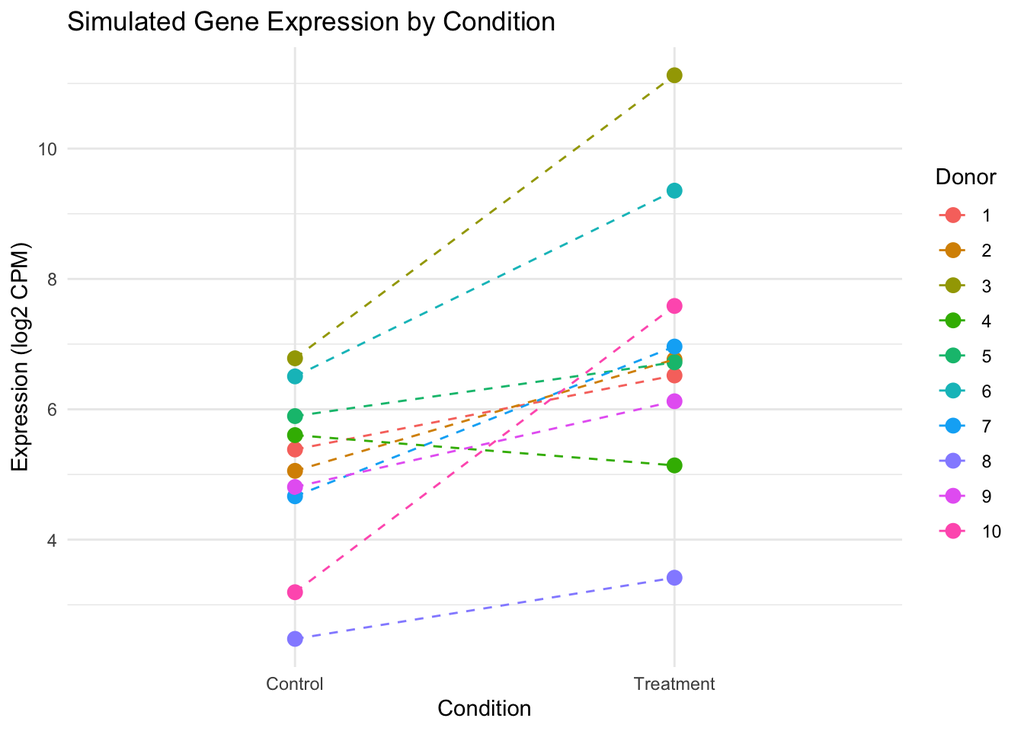

```r
library(ggplot2)

ggplot(rna_data, aes(x = Condition, y = Expression, group = Donor)) +
  geom_point(aes(color = Donor), size = 3) +
  geom_line(aes(color = Donor), linetype = "dashed") +
  labs(title = "Simulated Gene Expression by Condition",
       x = "Condition",
       y = "Expression (log2 CPM)") +
  theme_minimal()
```

Intuitive Points: - Each line represents a donor’s expression profile. - The treatment effect should shift the Treatment samples upward compared to Control. - Variability across donors is captured by the random effects.

### Fitting a Linear Mixed Effects Model

```r
library(lme4)

# Fit the mixed effects model
model <- lmer(Expression ~ Condition + (1 | Donor), data = rna_data)
summary(model)
```

```
## Linear mixed model fit by REML ['lmerMod']
## Formula: Expression ~ Condition + (1 | Donor)
##    Data: rna_data
##
## REML criterion at convergence: 72.1
##
## Scaled residuals:
##      Min       1Q   Median       3Q      Max
## -1.24790 -0.40709 -0.06082  0.40537  1.72975
##
## Random effects:
##  Groups   Name        Variance Std.Dev.
##  Donor    (Intercept) 1.945    1.394
##  Residual             1.214    1.102
## Number of obs: 20, groups:  Donor, 10
##
## Fixed effects:
##                    Estimate Std. Error t value
## (Intercept)          5.0368     0.5620   8.962
## ConditionTreatment   1.9343     0.4928   3.925
##
## Correlation of Fixed Effects:
##             (Intr)
## CndtnTrtmnt -0.438
```

### Discussion

#### Intuitive Points:

- The fixed effect for Condition estimates the overall treatment effect.
- The random effect for Donor adjusts for between-donor variability.
- This approach yields more reliable inference in paired designs than a simple linear model would.

#### Incorporating Covariance Random Effects (Kinship)

- Kinship: In real-world studies, donors might be genetically related. A kinship matrix quantifies this relatedness.
- Why It Matters:
- Ignoring relatedness can lead to false positive DEG detection.
- Kimma allows incorporating covariance random effects (like kinship) to adjust for these relationships.
- Note: While our simulation does not include a kinship matrix, the Kimma package is designed to handle it seamlessly when available.

#### Key Takeaways

- Flexible Modeling: Kimma integrates fixed effects, random effects, and even covariance random effects into a unified framework for RNA-seq.
- Paired Designs: Accounting for donor variability via random effects improves the detection of true treatment effects.
- Adjustment for Relatedness: Incorporating kinship (or other covariance structures) can further refine DEG analysis in genetically structured cohorts.
- Practical Workflow: Kimma’s consistent syntax and fit metrics (e.g., AIC) aid in model selection and interpretation.

#### Discussion & Reflection

- How might including a kinship matrix change the analysis in a study with related donors?
- What are the benefits of using a mixed effects model compared to a simple fixed effects model in paired designs?
- Can you think of other scenarios where accounting for random effects is critical?

## Lesson 6: Exploring Type S and Type M Errors in Statistical Inference

### Overview

#### Objectives

- Understand traditional error types (Type I and Type II) and introduce:
  - **Type S Errors:** Mistaken sign (direction) of an effect.
  - **Type M Errors:** Overestimation of the magnitude of an effect.
- Learn why low-powered studies can produce misleading significant results.

#### Topics Covered

- **Recap of Type I & II Errors:**  
  False positives and negatives.
- **Type S (Sign) Errors:**  
  Errors in the direction of effect.
- **Type M (Magnitude) Errors:**  
  Overestimation of effect size.
- **Simulation Insights:**  
  Impact of signal-to-noise ratio.

#### Activities

- Simulation or graphical examples demonstrating Type S and M errors.
- Discussion on improving interpretation through uncertainty quantification.

### Recap of Traditional Errors

- **Type I Error:** False positive—rejecting a true null hypothesis.
- **Type II Error:** False negative—failing to reject a false null hypothesis.

*However, even when a result is “significant”:*

- **Type S Error:** The estimated effect might have the wrong sign.
- **Type M Error:** The estimated effect might exaggerate the true effect size.

### Intuition Behind Type S and Type M Errors

- **Low-Power Studies:**  
  When true effects are small and sample sizes are low, statistically significant results may be unreliable.
- **Type S (Sign) Errors:**  
  The probability that the sign (direction) of the estimated effect is opposite to the true effect.
- **Type M (Magnitude) Errors:**  
  The factor by which the magnitude of the estimated effect exaggerates the true effect.

### Simulation Study Setup

We simulate a scenario with: - A small true effect (e.g., 0.5). - Relatively high noise. - A small sample size, leading to low statistical power.

We will: - Run many simulations. - Compute the proportion of significant results with the wrong sign (Type S error rate). - Compute the average exaggeration factor (Type M error).

```r
set.seed(123)

# Parameters
true_effect <- 0.5    # Small true effect size
sigma <- 1            # Standard deviation of noise
n <- 20               # Small sample size
alpha <- 0.05         # Significance level
n_sim <- 10000        # Number of simulation runs

# Containers for simulation results
estimates <- numeric(n_sim)
p_values <- numeric(n_sim)

# Simulation loop
for(i in 1:n_sim){
  # Simulate data from a normal distribution with mean true_effect
  y <- rnorm(n, mean = true_effect, sd = sigma)
  # Conduct a one-sample t-test (testing if mean differs from 0)
  test <- t.test(y, mu = 0)
  estimates[i] <- test$estimate
  p_values[i] <- test$p.value
}

# Identify significant results
significant <- p_values < alpha
n_sig <- sum(significant)

# Type S error: Proportion of significant estimates that are negative
type_S_rate <- mean(estimates[significant] < 0)

# Type M error: Exaggeration factor among significant estimates
# (i.e., the average ratio of |estimated effect| to the true effect)
type_M_exaggeration <- mean(abs(estimates[significant]) / true_effect)

cat("Total simulations:", n_sim, "\n")
```

```
## Total simulations: 10000
```

```r
cat("Significant results:", n_sig, "\n")
```

```
## Significant results: 5636
```

```r
cat("Type S error rate (wrong sign):", round(type_S_rate, 3), "\n")
```

```
## Type S error rate (wrong sign): 0
```

```r
cat("Type M exaggeration factor:", round(type_M_exaggeration, 3), "\n")
```

```
## Type M exaggeration factor: 1.298
```

### Visualizing the Significant Estimates

Let’s plot the distribution of the significant estimates and compare them to the true effect.

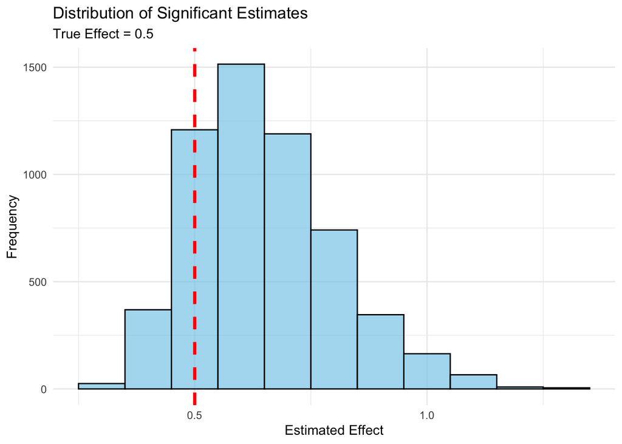

```r
library(ggplot2)

# Create a data frame of significant estimates
sig_data <- data.frame(Estimate = estimates[significant])

ggplot(sig_data, aes(x = Estimate)) +
  geom_histogram(binwidth = 0.1, fill = "skyblue", color = "black", alpha = 0.7) +
  geom_vline(xintercept = true_effect, color = "red", linetype = "dashed", size = 1.2) +
  labs(title = "Distribution of Significant Estimates",
       subtitle = paste("True Effect =", true_effect),
       x = "Estimated Effect",
       y = "Frequency") +
  theme_minimal()
```

### Discussion & Reflection

- Why do low-powered studies increase the chance of Type S and Type M errors?
- How might acknowledging these errors change the way you interpret significant findings?
- What strategies could you use in study design or analysis to mitigate these issues?

## Lesson 7: Synthesis – Common Themes and Best Practices

### Overview

#### Objectives

- Integrate key concepts from all lessons.
- Identify common threads in model building, uncertainty quantification, and inference.
- Develop a checklist of best practices for robust data analysis in complex settings.

#### Topics Covered

- **Advanced Modeling for Complex Data:**  
  Multilevel, mixed effects, and covariance structures.
- **Beyond P-values – Emphasizing Uncertainty:**  
  Reporting uncertainty and effect sizes.
- **Model Diagnostics & Fit Metrics:**  
  Using AIC, BIC, simulation-based calibration.
- **Communication of Assumptions:**  
  Using intuitive measures (e.g., R²) to guide analysis.

#### Activities

- Create a flowchart outlining a robust analysis pipeline.
- Develop a checklist of best practices for study design and data analysis.

### Recap: Lesson 1 – Basic Statistical Modeling

- **Key Concepts:**
  - Statistical models simplify real-world relationships.
  - Linear regression estimates relationships with predictors, responses, and an error term.
  - Uncertainty is expressed via confidence intervals and standard errors.
- **Takeaway:**  
  Begin with a simple model, always acknowledge uncertainty.

### Recap: Lesson 2 – Bayesian Inference and Regularization

- **Key Concepts:**
  - Bayesian inference updates prior beliefs with data to form a posterior.
  - Regularization/shrinkage helps prevent overfitting by pulling noisy estimates toward a central value.
- **Takeaway:**  
  Bayesian methods allow for more nuanced, probabilistic interpretations of uncertainty.

### Recap: Lesson 3 – Multilevel (Hierarchical) Models

- **Key Concepts:**
  - Multilevel models handle grouped data with fixed (overall) and random (group-specific) effects.
  - Partial pooling borrows strength across groups for more stable estimates.
- **Takeaway:**  
  In clustered data, hierarchical modeling better represents the data structure and improves inference.

### Recap: Lesson 4 – The R2D2M2 Prior

- **Key Concepts:**
  - R² is used to specify an intuitive prior on the overall explained variance.
  - Global shrinkage ($\tau^2$) sets the overall level of regularization.
  - Local shrinkage (via a Dirichlet decomposition) allocates variance to individual predictors.
- **Takeaway:**  
  Linking priors to interpretable quantities (like R²) helps in communicating and setting regularization.

### Recap: Lesson 5 – The Kimma Framework for RNA-seq Analysis

- **Key Concepts:**
  - RNA-seq data is high-dimensional and complex, often requiring mixed effects models.
  - Kimma integrates fixed effects, random effects (e.g., donor variability), and covariance random effects (e.g., kinship).
  - Model fit metrics (e.g., AIC) assist in choosing the best model.
- **Takeaway:**  
  Flexible modeling frameworks improve reliability in high-dimensional, structured data.

### Recap: Lesson 6 – Type S and Type M Errors

- **Key Concepts:**
  - **Type S errors:** Occur when the estimated effect has the wrong sign.
  - **Type M errors:** Occur when the effect size is overestimated.
  - Low-powered studies are prone to these errors.
- **Takeaway:**  
  Beyond p-values, understanding error types is essential for credible inference.

### Common Themes Across Lessons

- **Emphasis on Uncertainty:**  
  All methods stress that estimates come with uncertainty—whether through confidence intervals, posterior distributions, or error type quantification.
- **Regularization and Shrinkage:**  
  Techniques like Bayesian shrinkage (Lesson 2) and the R2D2M2 prior (Lesson 4) are designed to prevent overfitting and to ensure that only robust signals stand out.
- **Hierarchical Structures:**  
  Whether in multilevel models (Lesson 3) or in complex RNA-seq analyses (Lesson 5), accounting for data structure (e.g., clustering, kinship) is crucial.
- **Beyond Traditional Significance:**  
  The work on Type S/M errors (Lesson 6) encourages moving away from simple p-value thresholds to a richer understanding of effect reliability.

### Best Practices for Robust Analysis

1. **Model Building:**
   - Choose models that match the data structure (e.g., multilevel for grouped data).
   - Consider both fixed and random effects when applicable.
2. **Regularization:**
   - Use shrinkage priors to mitigate overfitting.
   - Express prior beliefs with interpretable measures (e.g., using R²).
3. **Uncertainty Quantification:**
   - Report and interpret confidence intervals or credible intervals.
   - Understand and assess Type S and Type M errors, especially in low-powered studies.
4. **Model Diagnostics:**
   - Use metrics like AIC, BIC, and simulation-based calibration to evaluate model fit.
   - Visualize residuals and effect distributions.
5. **Communication:**
   - Clearly convey assumptions and the uncertainty inherent in estimates.
   - Use intuitive visuals (e.g., flowcharts, histograms) to explain model behavior.

#### Flowchart: A Robust Analysis Pipeline

**Step 1: Data Exploration** - Visualize data, check for group structures and outliers.

**Step 2: Model Specification** - Choose an appropriate model (simple regression, multilevel, mixed effects). - Define fixed effects and random effects.

**Step 3: Incorporate Regularization** - Select shrinkage priors (e.g., R2D2M2) or regularization methods. - Specify interpretable hyperparameters.

**Step 4: Model Fitting & Diagnostics** - Fit the model using appropriate software (e.g., R, Stan). - Evaluate model fit with AIC/BIC and simulation-based calibration.

**Step 5: Inference & Uncertainty** - Report estimates with confidence/credible intervals. - Quantify and discuss potential Type S/M errors.

**Step 6: Communication & Decision Making** - Use visualizations to explain findings. - Consider implications for scientific conclusions.

## Additional Resources and Next Steps

### Supplementary Readings

- Introductory texts on Bayesian statistics.
- Materials on hierarchical modeling.
- Tutorials on RNA-seq data analysis.

### Practical Exercises

- Implement simple models in R (e.g., using `lme4` or `brms`).
- Work on hands-on examples from each lesson.

### Discussion & Reflection

- How would you apply these methods to your own data?
- What challenges do you foresee in real-world applications?